Practical data science with R built chapter 6 built a number of single variable models. In Listing 6.11 it used an ad-hoc entropy based out of sample effect size estimate for variable selection. This likely (though it isn’t completely rigorous) picked variables conservatively. We show here how to repeat this work on the KDD2009 dataset using more standard techniques more quickly. For vtreat details see: http://www.win-vector.com/blog/2014/08/vtreat-designing-a-package-for-variable-treatment/ and Chapter 6 of Practical Data Science with R: http://www.amazon.com/Practical-Data-Science/dp/1617291560 For details on data see: https://github.com/WinVector/zmPDSwR/tree/master/KDD2009 There is an issue that any data row used to build the single variable models isn’t exchangable with future unseen rows for the purposes of scoring and training. So the most hygienic way to work is to use one subset of data to build the single variable models, and then another to built the composite model, and a third for scoring. In particular models trained using rows used to build sub-models think the sub-models have large effects that the sub-models will in the future, and under-estimate degrees of freedom of complicated sub-models.

```r
#load some libraries
# http://www.win-vector.com/blog/2014/08/vtreat-designing-a-package-for-variable-treatment/
# devtools::install_github("WinVector/vtreat")
library('vtreat')
# devtools::install_github("WinVector/vtreat")
library('WVPlots')
library('parallel')
library('gbm')
library('class')


# load the data as in the book
# change this path to match your directory structure
dir = '~/Documents/work/PracticalDataScienceWithR/zmPDSwR/KDD2009/'

d = read.table(paste(dir,'orange_small_train.data.gz',sep=''),
                header=T,sep='\t',na.strings=c('NA',''),
               stringsAsFactors=FALSE)
churn = read.table(paste(dir,'orange_small_train_churn.labels.txt',sep=''),
                    header=F,sep='\t')
d$churn = churn$V1
appetency = read.table(paste(dir,'orange_small_train_appetency.labels.txt',sep=''),
                        header=F,sep='\t')
d$appetency = appetency$V1
upselling = read.table(paste(dir,'orange_small_train_upselling.labels.txt',sep=''),
                        header=F,sep='\t')
d$upselling = upselling$V1
set.seed(729375)
d$rgroup = runif(dim(d)[[1]])
dTrainM = subset(d,rgroup<=0.5)  # set for building models
dTrainC = subset(d,(rgroup>0.5) & (rgroup<=0.9)) # set for impact coding
dTest = subset(d,rgroup>0.9) # set for evaluation
rm(list=c('d','churn','appetency','upselling','dir'))
outcomes = c('churn','appetency','upselling')
vars = setdiff(colnames(dTrainM),
                c(outcomes,'rgroup'))
yName = 'churn'
yTarget = 1
```

```r
# build data treatments

set.seed(239525)

cl = parallel::makeCluster(4)

# build treatments on all training data (coding and modeling)
treatmentsA = designTreatmentsC(rbind(dTrainC,dTrainM),
    vars,yName,yTarget,
    smFactor=2.0,
    parallelCluster=cl,
    scoreVars=TRUE)
```

```
## [1] "desigining treatments Tue Aug  4 23:28:38 2015"
## [1] "scoring columns Tue Aug  4 23:28:56 2015"
## [1] "have treatment plan Tue Aug  4 23:31:58 2015"
```

```r
# build treatments on just the coding data
treatmentsC = designTreatmentsC(dTrainC,
    vars,yName,yTarget,
    smFactor=2.0,
    parallelCluster=cl,
    scoreVars=TRUE)
```

```
## [1] "desigining treatments Tue Aug  4 23:31:58 2015"
## [1] "scoring columns Tue Aug  4 23:32:05 2015"
## [1] "have treatment plan Tue Aug  4 23:33:21 2015"
```

```r
if(!is.null(cl)) {
    parallel::stopCluster(cl)
    cl = NULL
}
```

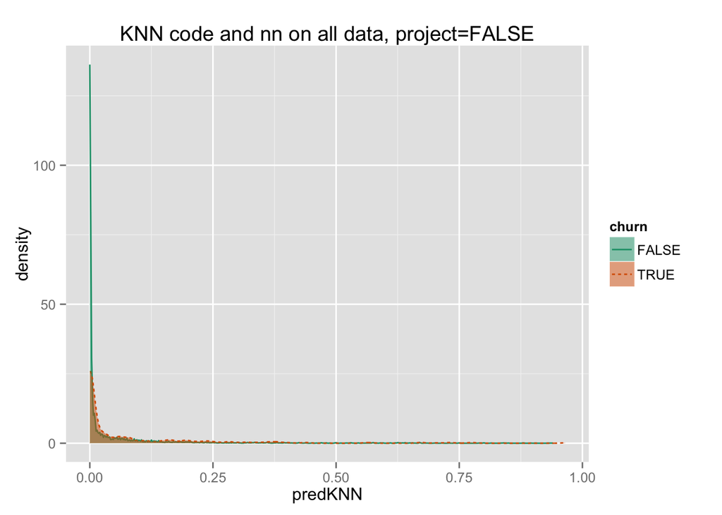

```r
# Repeat something similar to the
# work of Section 6.3.3 of Practical Data Science with R
# http://www.practicaldatascience.com/
# We (deliberately) repeat the error of using the same
# data to build the initial single variable models
# (here called treated variables).  This example seems to
# suffer more than the book did, likely due to the books use
# of an entropy based out of sample effect size based variable
# selection (different than vtreat's current variable scoring function).
# Likely the book KNN model was shielded a bit by the smaller number
# of variables, and simpler variables the book criterion (listing 6.11)
# picked.
# We see test AUC 0.59 here, versus the book's test AUC 0.72 for KNN.
kddPrune=0.9999
nK = 200
project = FALSE
knnTrain = prepare(treatmentsA,
                   rbind(dTrainC,dTrainM),
                   scale=TRUE,
                   pruneLevel=kddPrune)
selvars = setdiff(colnames(knnTrain),yName)
knnCl = knnTrain[[yName]]==yTarget

knnTest = prepare(treatmentsA,
                  dTest,
                  scale=TRUE,
                  pruneLevel=kddPrune)
if(project) {
  # project may help with duplicated variables.
  # with scale=TRUE we are in y-units, so this is a y-aware reduction
  pcomp = prcomp(knnTrain[,selvars])
  goodP = (pcomp$sdev>=1.0e-2) & (seq_len(length(pcomp$sdev))<=10)
  projection = pcomp$rotation[,goodP]
  pvars = colnames(projection)
  knnTrainP = as.data.frame(as.matrix(knnTrain[,selvars]) %*% projection)
  knnTestP = as.data.frame(as.matrix(knnTest[,selvars]) %*% projection)
  selvars <- pvars[goodP]
} else {
  knnTrainP = knnTrain
  knnTestP = knnTest
}

knnPred = function(df) {
    knnDecision = knn(knnTrainP[,selvars],df[,selvars],knnCl,k=nK,prob=T)
    ifelse(knnDecision==TRUE,
       attributes(knnDecision)$prob,
       1-(attributes(knnDecision)$prob))
}
knnTestP$predKNN = knnPred(knnTestP)
knnTestP[[yName]] = knnTest[[yName]]==yTarget
ti = paste('KNN code and nn on all data, project=',project,sep='')
print(DoubleDensityPlot(knnTestP, 'predKNN', yName,
                               title=ti))
```

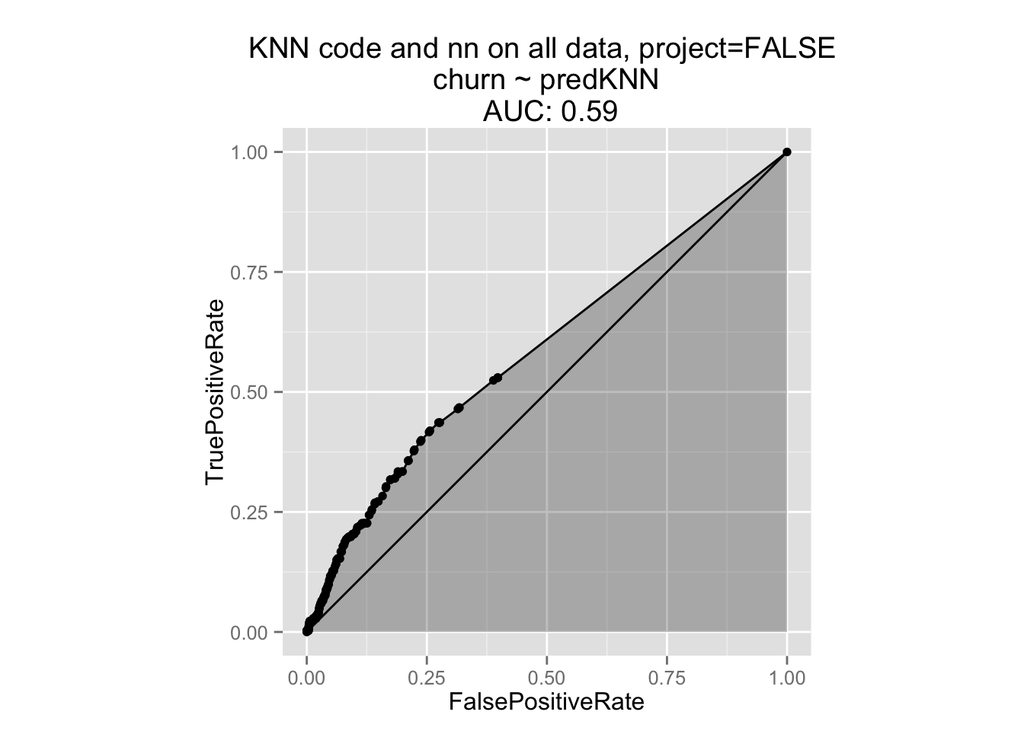

```r
print(ROCPlot(knnTestP, 'predKNN', yName,
                     title=ti))
```

```r
# see on AUC of 0.59, not as good as the book's 0.72
```

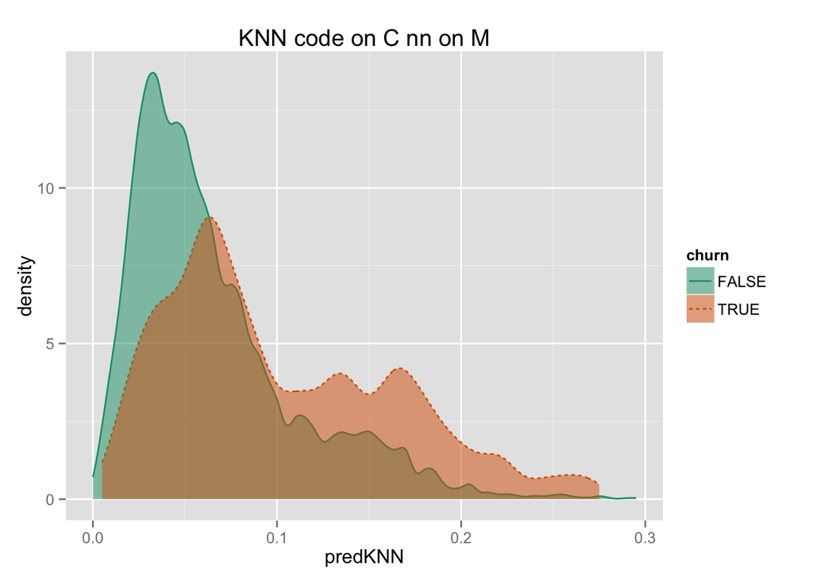

```r
# As we said: one flaw in both the original
# the older book code: we are using the same data rows
# to both impact code (see:
# http://www.win-vector.com/blog/2012/07/modeling-trick-impact-coding-of-categorical-variables-with-many-levels/ )
# categorical variables and to model.
#
# We now strongly recommend splitting your training set into two pieces,
# and using one piece for the vtreat::prepare() step, and only the other
# disjoint portion of the training data for model construction. The
# issue is any row of data examined during vtreat::prepare() is no
# longer exchangeable with even test data (let alone future data),
# especially for impact codes for very large categorical
# variables. Models trained on rows used to build the variable encodings
# tend to over-estimate effect sizes of the sub-models (or treated
# variables), under-estimate degrees of freedom, and get significances
# wrong.
#
# Fix: separate coding and training, as shown here
# Brings test score immediately up to 0.68.

kddPrune=0.999
nK = 200
knnTrain = prepare(treatmentsC,
                   dTrainM,
                   scale=TRUE,
                   pruneLevel=kddPrune)
selvars = setdiff(colnames(knnTrain),yName)
knnCl = knnTrain[[yName]]==yTarget

knnTest = prepare(treatmentsC,
                  dTest,
                  scale=TRUE,
                  pruneLevel=kddPrune)

knnPred = function(df) {
    knnDecision = knn(knnTrain[,selvars],df[,selvars],knnCl,k=nK,prob=T)
    ifelse(knnDecision==TRUE,
       attributes(knnDecision)$prob,
       1-(attributes(knnDecision)$prob))
}
knnTest$predKNN = knnPred(knnTest)
knnTest[[yName]] = knnTest[[yName]]==yTarget
ti = 'KNN code on C nn on M'
print(DoubleDensityPlot(knnTest, 'predKNN', yName,
                               title=ti))
```

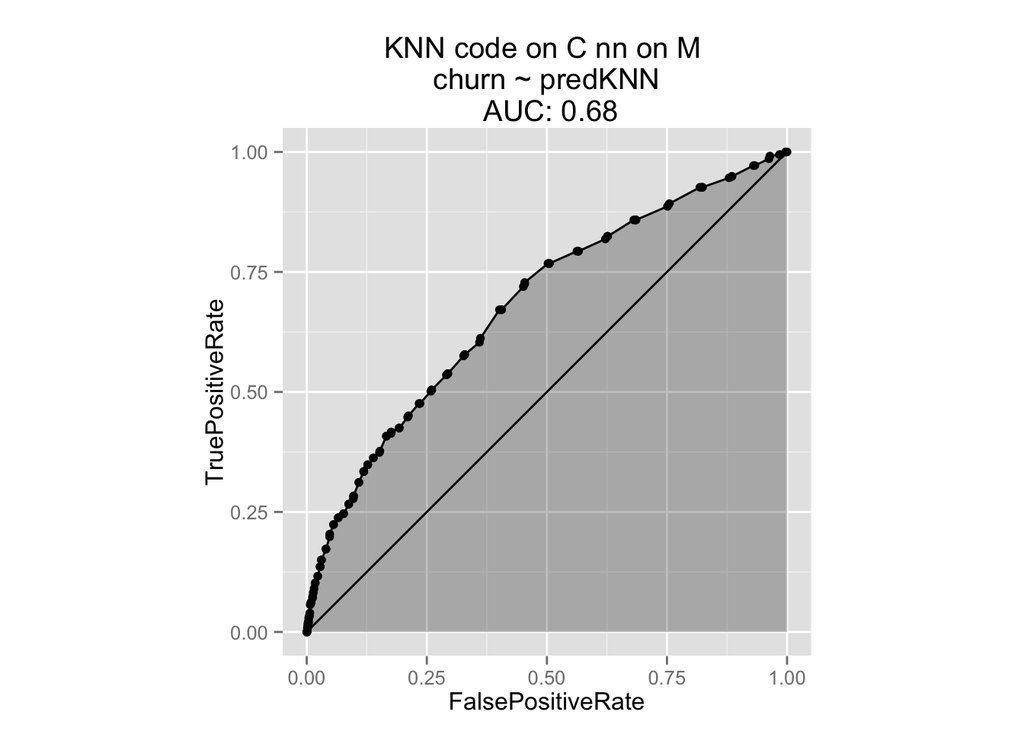

```r
print(ROCPlot(knnTest, 'predKNN', yName,
                     title=ti))
```